# Lab_5_2

## Lab 5 Wide and Deep Networks

### Team Members: Aitor Gonzalez (49092725), Palmer Nelson (47066829), Abdul Wasay (49121481)

### [1 points] Define and prepare your class variables. Use proper variable representations (int, float, one-hot, etc.). Use pre-processing methods (as needed) for dimensionality reduction, scaling, etc. Remove variables that are not needed/useful for the analysis. Describe the final dataset that is used for classification/regression (include a description of any newly formed variables you created). You have the option of using tf.dataset for processing, but it is not required.

We using the mushroom dataset that utilizes different characteristics of mushrooms to classify them as posionous or edilble. It can be found here: https://www.kaggle.com/datasets/uciml/mushroom-classification/data

```python
import pandas as pd
import pprint
from copy import deepcopy


data = pd.read_csv('mushrooms.csv')
#print (data.head())

print(data.info())

missing_values = data.isnull().sum()
pp = pprint.PrettyPrinter(indent=6)
pp.pprint(data)
print(missing_values)
```

```
<class 'pandas.core.frame.DataFrame'>
RangeIndex: 8124 entries, 0 to 8123
Data columns (total 23 columns):
 #   Column                    Non-Null Count  Dtype
---  ------                    --------------  -----
 0   class                     8124 non-null   object
 1   cap-shape                 8124 non-null   object
 2   cap-surface               8124 non-null   object
 3   cap-color                 8124 non-null   object
 4   bruises                   8124 non-null   object
 5   odor                      8124 non-null   object
 6   gill-attachment           8124 non-null   object
 7   gill-spacing              8124 non-null   object
 8   gill-size                 8124 non-null   object
 9   gill-color                8124 non-null   object
 10  stalk-shape               8124 non-null   object
 11  stalk-root                8124 non-null   object
 12  stalk-surface-above-ring  8124 non-null   object
 13  stalk-surface-below-ring  8124 non-null   object
 14  stalk-color-above-ring    8124 non-null   object
 15  stalk-color-below-ring    8124 non-null   object
 16  veil-type                 8124 non-null   object
 17  veil-color                8124 non-null   object
 18  ring-number               8124 non-null   object
 19  ring-type                 8124 non-null   object
 20  spore-print-color         8124 non-null   object
 21  population                8124 non-null   object
 22  habitat                   8124 non-null   object
dtypes: object(23)
memory usage: 1.4+ MB
None
     class cap-shape cap-surface cap-color bruises odor gill-attachment  \
0        p         x           s         n       t    p               f
1        e         x           s         y       t    a               f
2        e         b           s         w       t    l               f
3        p         x           y         w       t    p               f
4        e         x           s         g       f    n               f
...    ...       ...         ...       ...     ...  ...             ...
8119     e         k           s         n       f    n               a
8120     e         x           s         n       f    n               a
```

[output cut: 53 more lines]

```
gill-color                  0
stalk-shape                 0
stalk-root                  0
stalk-surface-above-ring    0
stalk-surface-below-ring    0
stalk-color-above-ring      0
stalk-color-below-ring      0
veil-type                   0
veil-color                  0
ring-number                 0
ring-type                   0
spore-print-color           0
population                  0
habitat                     0
dtype: int64
```

```python
categorical_cols = data.select_dtypes(include=['object']).columns
print(categorical_cols)
```

```
Index(['class', 'cap-shape', 'cap-surface', 'cap-color', 'bruises', 'odor',
       'gill-attachment', 'gill-spacing', 'gill-size', 'gill-color',
       'stalk-shape', 'stalk-root', 'stalk-surface-above-ring',
       'stalk-surface-below-ring', 'stalk-color-above-ring',
       'stalk-color-below-ring', 'veil-type', 'veil-color', 'ring-number',
       'ring-type', 'spore-print-color', 'population', 'habitat'],
      dtype='object')
```

Column for class to be predicted: class

Onehot encoding columns for shape of mushroom cap: cap-shape_b, cap-shape_c, cap-shape_f, cap-shape_k, cap-shape_s, cap-shape_x, cap-surface_f, cap-surface_g, cap-surface_s, cap-surface_y

Onehot encoding columns for color of mushroom cap: cap-color_b, cap-color_c, cap-color_e, cap-color_g, cap-color_n, cap-color_p, cap-color_r, cap-color_u, cap-color_w, cap-color_y

Onehot encoding for bruising on mushroom: bruises_f, bruises_t

Onehot encoding columns for smell of mushroom: odor_a, odor_c, odor_f, odor_l, odor_m, odor_n, odor_p, odor_s, odor_y

Onehot encoding columns for attachment of mushroom gill: gill-attachment_a, gill-attachment_f

Onehot encoding columns for spacing of mushroom gill: gill-spacing_c, gill-spacing_w,

Onehot encoding columns for size of mushroom gill: gill-size_b, gill-size_n,

Onehot encoding columns for color of mushroom gill: gill-color_b, gill-color_e, gill-color_g, gill-color_h, gill-color_k, gill-color_n, gill-color_o, gill-color_p, gill-color_r, gill-color_u, gill-color_w, gill-color_y

Onehot encoding columns for shape of mushroom stalk: stalk-shape_e, stalk-shape_t

Onehot encoding columns for root of mushroom stalk: stalk-root_?, stalk-root_b, stalk-root_c, stalk-root_e, stalk-root_r,

Onehot encoding columns for surface of mushroom stalk above ring: stalk-surface-above-ring_f, stalk-surface-above-ring_k, stalk-surface-above-ring_s, stalk-surface-above-ring_y

Onehot encoding columns for surface of mushroom stalk below ring: stalk-surface-below-ring_f, stalk-surface-below-ring_k, stalk-surface-below-ring_s, stalk-surface-below-ring_y,

Onehot encoding columns for color of mushroom stalk above ring: stalk-color-above-ring_b, stalk-color-above-ring_c, stalk-color-above-ring_e, stalk-color-above-ring_g, stalk-color-above-ring_n, stalk-color-above-ring_o, stalk-color-above-ring_p, stalk-color-above-ring_w, stalk-color-above-ring_y

Onehot encoding columns for color of mushroom stalk below ring: stalk-color-below-ring_b, stalk-color-below-ring_c, stalk-color-below-ring_e, stalk-color-below-ring_g, stalk-color-below-ring_n, stalk-color-below-ring_o, stalk-color-below-ring_p, stalk-color-below-ring_w, stalk-color-below-ring_y

Onehot encoding columns for veil type of mushroom: veil-type_p, veil-color_n, veil-color_o, veil-color_w, veil-color_y

Onehot encoding columns for number of rings on mushroom: ring-number_n, ring-number_o, ring-number_t, ring-type_e, ring-type_f, ring-type_l, ring-type_n, ring-type_p

Onehot encoding columns for type of color of the mushroom's spores: spore-print-color_b, spore-print-color_h, spore-print-color_k, spore-print-color_n, spore-print-color_o, spore-print-color_r, spore-print-color_u, spore-print-color_w, spore-print-color_y

Onehot encoding columns for population of the mushroom: population_a, population_c, population_n, population_s, population_v, population_y

Onehot encoding columns for habitat of the mushroom: habitat_d, habitat_g, habitat_l, habitat_m, habitat_p, habitat_u, habitat_w

### [1 points] Identify groups of features in your data that should be combined into cross-product features. Provide a compelling justification for why these features should be crossed (or why some features should not be crossed).

#### We can combine the following features to help our network perform more effectively:

1. cap-shape, cap-surface, cap-color: These features all relate to the physical appearance of the mushroom cap. Combining them could help the model better understand patterns related to the cap's appearance, which might be indicative of whether a mushroom is poisonous.
2. stalk-shape, stalk-root, stalk-surface-above-ring, stalk-surface-below-ring, stalk-color-above-ring, stalk-color-below-ring: Similar to the cap features, these stalk features could be combined to provide a more comprehensive view of the stalk's characteristics in order to predict the poisonous nature of the mushroom.
3. veil-type, veil-color: combination of veil type and color refering to the same part of the mushroom may yield specific combinations that help determine the poisonous nature of the mushroom.
4. ring-number, ring-type: The number and type of rings can be combined, as certain types of rings might only occur a specific number of times.

#### We will not combine the following features to as they may not be very well related to each other and would provide their own particular insights into the nature of the mushroom:

1. odor, gill-color, spore-print-color, habitat, population

#### Additional notes

We could explore interactions between some of these uncrossed features and others. For example, the odor of a mushroom, could interact with features like gill-color or spore-print-color to provide unique insights. Especially since odor is a strong indicator of edibility in many mushroom species.

```python
from sklearn.model_selection import train_test_split
import tensorflow as tf

# Combine cap features
data['cap_combined'] = data['cap-shape'].astype(str) + '_' + data['cap-surface'].astype(str) + '_' + data['cap-color'].astype(str)

# Combine stalk features
data['stalk_combined'] = data['stalk-shape'].astype(str) + '_' + data['stalk-root'].astype(str) + '_' + data['stalk-surface-above-ring'].astype(str) + '_' + data['stalk-surface-below-ring'].astype(str) + '_' + data['stalk-color-above-ring'].astype(str) + '_' + data['stalk-color-below-ring'].astype(str)

# Combine veil features
data['veil_combined'] = data['veil-type'].astype(str) + '_' + data['veil-color'].astype(str)

# Combine ring features
data['ring_combined'] = data['ring-number'].astype(str) + '_' + data['ring-type'].astype(str)

# Columns to drop after combining
columns_to_drop = [
    'cap-shape', 'cap-surface', 'cap-color',
    'stalk-shape', 'stalk-root', 'stalk-surface-above-ring', 'stalk-surface-below-ring', 'stalk-color-above-ring', 'stalk-color-below-ring',
    'veil-type', 'veil-color',
    'ring-number', 'ring-type'
]

data.drop(columns=columns_to_drop, axis=1, inplace=True)

print(data.head())
```

```
  class bruises odor gill-attachment gill-spacing gill-size gill-color  \
0     p       t    p               f            c         n          k
1     e       t    a               f            c         b          k
2     e       t    l               f            c         b          n
3     p       t    p               f            c         n          n
4     e       f    n               f            w         b          k

  spore-print-color population habitat cap_combined stalk_combined  \
0                 k          s       u        x_s_n    e_e_s_s_w_w
1                 n          n       g        x_s_y    e_c_s_s_w_w
2                 n          n       m        b_s_w    e_c_s_s_w_w
3                 k          s       u        x_y_w    e_e_s_s_w_w
4                 n          a       g        x_s_g    t_e_s_s_w_w

  veil_combined ring_combined
0           p_w           o_p
1           p_w           o_p
2           p_w           o_p
3           p_w           o_p
4           p_w           o_e
```

```python
#prevent class from being one hot encoded
class_data = data['class']
data = data.drop('class', axis=1)


# One Hot Encode the dataset with the combined features
data_encoded = pd.get_dummies(data)

data_encoded['class'] = class_data

print(data_encoded.head())
```

```
   bruises_f  bruises_t  odor_a  odor_c  odor_f  odor_l  odor_m  odor_n  \
0      False       True   False   False   False   False   False   False
1      False       True    True   False   False   False   False   False
2      False       True   False   False   False    True   False   False
3      False       True   False   False   False   False   False   False
4       True      False   False   False   False   False   False    True

   odor_p  odor_s  ...  veil_combined_p_w  veil_combined_p_y  \
0    True   False  ...               True              False
1   False   False  ...               True              False
2   False   False  ...               True              False
3    True   False  ...               True              False
4   False   False  ...               True              False

   ring_combined_n_n  ring_combined_o_e  ring_combined_o_f  ring_combined_o_l  \
0              False              False              False              False
1              False              False              False              False
2              False              False              False              False
3              False              False              False              False
4              False               True              False              False

   ring_combined_o_p  ring_combined_t_e  ring_combined_t_p  class
0               True              False              False      p
1               True              False              False      e
2               True              False              False      e
3               True              False              False      p
4              False              False              False      e

[5 rows x 216 columns]
```

### [1 points] Choose and explain what metric(s) you will use to evaluate your algorithm’s performance. You should give a detailed argument for why this (these) metric(s) are appropriate on your data. That is, why is the metric appropriate for the task (e.g., in terms of the business case for the task). Please note: rarely is accuracy the best evaluation metric to use. Think deeply about an appropriate measure of performance.

Given the seriousness of falsely identifying a poisonous mushroom as edible, we would want to use recall. With the danger of consuming a poisonous mushroom, maximizing recall (minimizing false negatives) is best, however we do not want to classify all mushrooms as poisonous.

Hence we would also use area under the curve for the Receiver Operating Characteristic (ROC) curve. This helps to understand the trade-off between sensitivity (true positive rate) and specificity (true negative rate). Hence ROC AUC is a good measure of how well the model distinguishes between classes. A higher AUC indicates a better model at distinguishing poisonous and non-poisonous mushrooms.

A profitable application of this solution with our approach would be a foodstufs producer. The risk of even a small population of toxic mushrooms being present in a food production chain is great. When the process has been compromised it is standard procedure to destroy the entire batch to ensure the safety of the consumer. This has happened with numerous contaminations from diseases like swine and avian flue, as well as chemical side poullution from conservatives etc. The loss of the entire production, plus stopping the production line until the source has been located, purge the whole line, and restart it until the product reaches the customers again is often too great and the companies go under. An machien learning system that is reading these features from computer vision can check a conveyor belt where the produce is rolling in to identify any potential toxic units and stop the line for them to be purged. We can even run this in stages where a first filter can be more prone to false positives, and then those flagged go into a second cycle that can be more strict although perform significantly worse because it only works on a much smaller subset.

### [1 points] Choose the method you will use for dividing your data into training and testing (i.e., are you using Stratified 10-fold cross validation? Shuffle splits? Why?). Explain why your chosen method is appropriate or use more than one method as appropriate. Argue why your cross validation method is a realistic mirroring of how an algorithm would be used in practice. Use the method to split your data that you argue for.

```python
for column in data.columns:
    print(f"Value counts for column '{column}':")
    print(data[column].value_counts())
    print("\n")
```

```
Value counts for column 'bruises':
bruises
f    4748
t    3376
Name: count, dtype: int64


Value counts for column 'odor':
odor
n    3528
f    2160
y     576
s     576
a     400
l     400
p     256
c     192
m      36
Name: count, dtype: int64


Value counts for column 'gill-attachment':
gill-attachment
f    7914
a     210
Name: count, dtype: int64


Value counts for column 'gill-spacing':
gill-spacing
c    6812
w    1312
Name: count, dtype: int64


Value counts for column 'gill-size':
gill-size
b    5612
n    2512
Name: count, dtype: int64
```

[output cut: 92 more lines]

```
p_o      96
p_y       8
Name: count, dtype: int64


Value counts for column 'ring_combined':
ring_combined
o_p    3560
o_e    2584
o_l    1296
t_p     408
t_e     192
o_f      48
n_n      36
Name: count, dtype: int64
```

#### Although the final class prediction is evenly distributed, we can see that our original dataset has certain values that are under represented. In orde to balance them out for our training on the wide and deep netwrok, we elect to choose stratified K-fold

```python
from sklearn.model_selection import StratifiedKFold
X = data_encoded.drop('class', axis=1)
y = data_encoded['class']


# Stratified K-Fold Cross-Validation
skf = StratifiedKFold(n_splits=10, shuffle=True, random_state=42)

X_np = X.values
y_np = y.values

# This will store the performance metrics for each fold
fold_metrics = []

for train_index, test_index in skf.split(X_np, y_np):
    # Splitting data for this fold
    X_train, X_test = X_np[train_index], X_np[test_index]
    y_train, y_test = y_np[train_index], y_np[test_index]

    # Convert to TensorFlow Dataset
    train_dataset = tf.data.Dataset.from_tensor_slices((X_train, y_train))
    test_dataset = tf.data.Dataset.from_tensor_slices((X_test, y_test))

    # Batch and prefetch
    train_dataset = train_dataset.batch(32).prefetch(tf.data.AUTOTUNE)
    test_dataset = test_dataset.batch(32).prefetch(tf.data.AUTOTUNE)


#     print("TRAIN:", train_index, "TEST:", test_index)
```

We think stratified k fold is appropriate for several reasons:

Handling Imbalanced Features: As observed, some features in dataset have values that are underrepresented. Stratified K-Fold maintains the proportion of these underrepresented values in each fold, ensuring that each fold is a good representative of the whole dataset.

Robust Model Evaluation: Stratified K-Fold Cross-Validation provides a more robust evaluation of model's performance than a simple train/test split, especially in cases where the dataset isn't large. It allows the model to train and validate on different subsets of the data, reducing the chance of overfitting and providing a more accurate estimate of how the model will perform on unseen data.

Consistent Distribution of Target Variable: Given that target class (edible or poisonous) is evenly distributed, Stratified K-Fold will ensure that each fold has a similar distribution of the target variable. This is important for maintaining the integrity of the classification problem across all folds.

Practical Application: Using Stratified K-Fold prepares model to handle data set not evenly distributed effectively, making the validation process more aligned desired outcome.

### [2 points] Create at least three combined wide and deep networks to classify your data using Keras (this total of "three" includes the model you will train in the next step of the rubric). Visualize the performance of the network on the training data and validation data in the same plot versus the training iterations.

Note: you can use the "history" return parameter that is part of Keras "fit" function to easily access this data.

```python
import numpy as np
import tensorflow as tf
from tensorflow.keras.models import Model
from tensorflow.keras.layers import Input, Dense, concatenate
from tensorflow.keras.optimizers import Adam
from tensorflow.keras.metrics import Recall, AUC
from sklearn.model_selection import StratifiedKFold
from sklearn.metrics import confusion_matrix
from statsmodels.stats.contingency_tables import mcnemar
```

```python
def create_wide_and_deep_model(input_shape):
    # Wide part of the model
    wide_input = Input(shape=(input_shape,))
    wide_output = Dense(1, activation='sigmoid')(wide_input)

    # Deep part of the model
    deep_input = Input(shape=(input_shape,))
    hidden1 = Dense(128, activation='relu')(deep_input)
    hidden2 = Dense(64, activation='relu')(hidden1)
    deep_output = Dense(1, activation='sigmoid')(hidden2)

    # Combine wide and deep into one model
    merged = concatenate([wide_output, deep_output])
    output = Dense(1, activation='sigmoid')(merged)
    model = Model(inputs=[wide_input, deep_input], outputs=output)

    model.compile(optimizer=Adam(), loss='binary_crossentropy', metrics=['accuracy', Recall(name='recall'), AUC(name='auc')])
    return model

X = data_encoded.drop('class', axis=1)
y = data_encoded['class']
y = y.map({'p': 1, 'e': 0})

skf = StratifiedKFold(n_splits=10, shuffle=True, random_state=42)

X_np = X.values
y_np = y.values

fold_metrics = []
fold_histories = []
all_predictions_wide_deep = []

for train_index, test_index in skf.split(X_np, y_np):
    # Prepare data for this fold
    X_train, X_test = X_np[train_index], X_np[test_index]
    y_train, y_test = y_np[train_index], y_np[test_index]

    # Convert to TensorFlow Dataset
    train_dataset = tf.data.Dataset.from_tensor_slices(((X_train, X_train), y_train))
    test_dataset = tf.data.Dataset.from_tensor_slices(((X_test, X_test), y_test))

    # Batch and prefetch
    train_dataset = train_dataset.batch(32).prefetch(tf.data.AUTOTUNE)
    test_dataset = test_dataset.batch(32).prefetch(tf.data.AUTOTUNE)

    # Create a new instance of the model for this fold
    model = create_wide_and_deep_model(input_shape=X_train.shape[1])

    # Train the model
    history = model.fit(train_dataset, epochs=10, validation_data=test_dataset)

    # Evaluate the model on the test dataset and store the metrics
    metrics = model.evaluate(test_dataset)
    fold_metrics.append(metrics)
    fold_histories.append(history)

    # Predict on the test set and store predictions
    y_pred = model.predict(test_dataset).round()
    all_predictions_wide_deep.append((y_test, y_pred))

# Calculate the average of the metrics across all folds
average_metrics = np.mean(fold_metrics, axis=0)
print("Average Metrics Across All Folds:", average_metrics)

all_predictions_two_layer = all_predictions_wide_deep

mcnemar_results = []
for (y_test_wide_deep, y_pred_wide_deep), (y_test_two_layer, y_pred_two_layer) in zip(all_predictions_wide_deep, all_predictions_two_layer):
    # Construct the contingency table
    contingency_table = confusion_matrix(y_test_wide_deep, y_pred_wide_deep, labels=[1, 0]) + confusion_matrix(y_test_two_layer, y_pred_two_layer, labels=[1, 0])

    # Perform McNemar's test
    result = mcnemar(contingency_table)
    mcnemar_results.append(result.pvalue)

# Average the p-values
average_p_value = np.mean(mcnemar_results)
print("Average McNemar Test P-Value:", average_p_value)
```

```
Average Metrics Across All Folds: [0.17359551 1.         1.         0.99999999]
Average McNemar Test P-Value: 1.0
```

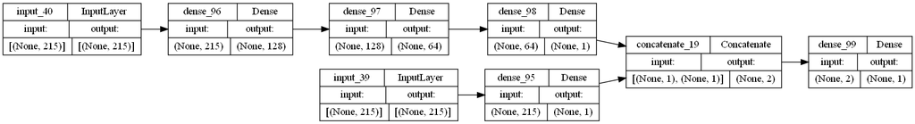

```python
from tensorflow.keras.utils import plot_model

plot_model(
    model, to_file='model.png', show_shapes=True, show_layer_names=True,
    rankdir='LR', expand_nested=False, dpi=96
)
```

```python
average_history = {}
num_epochs = 10

# Initialize a dictionary to store the sum of metrics across all folds
for key in fold_histories[0].history.keys():
    average_history[key] = [0] * num_epochs

# Sum up the metrics
for history in fold_histories:
    for key, values in history.history.items():
        for i, value in enumerate(values):
            average_history[key][i] += value

# Divide by the number of folds to get the average
for key in average_history.keys():
    average_history[key] = [x / len(fold_histories) for x in average_history[key]]
```

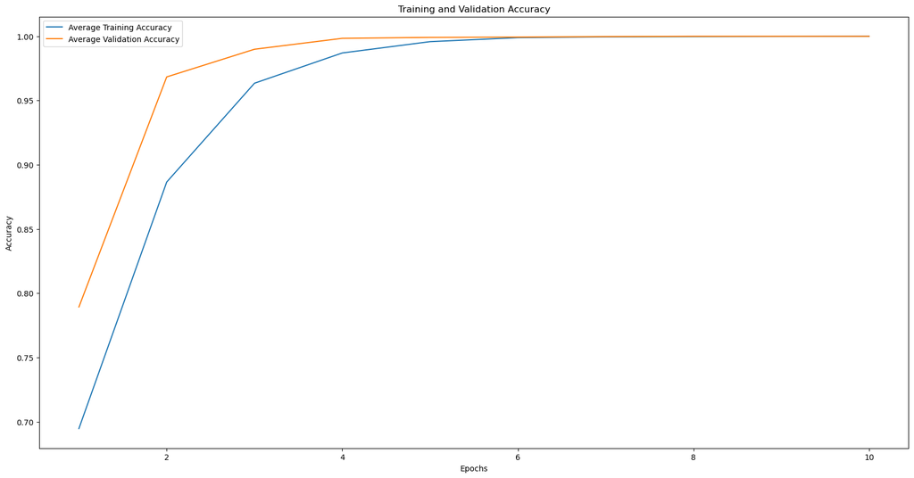

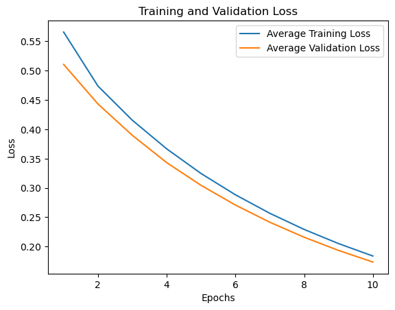

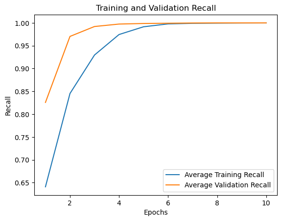

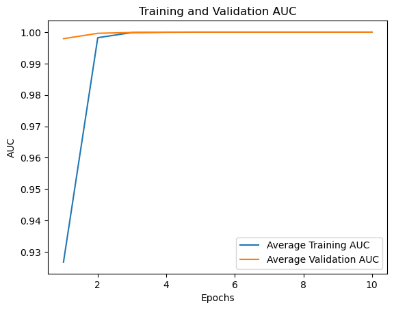

```python
import matplotlib.pyplot as plt

num_epochs = 10

# Plotting
plt.figure(figsize=(20, 10))

# Accuracy plot

plt.plot(range(1, num_epochs + 1), average_history['accuracy'], label='Average Training Accuracy')
if 'val_accuracy' in average_history:
    plt.plot(range(1, num_epochs + 1), average_history['val_accuracy'], label='Average Validation Accuracy')
plt.title('Training and Validation Accuracy')
plt.xlabel('Epochs')
plt.ylabel('Accuracy')
plt.legend()
plt.show()

# Loss plot

plt.plot(range(1, num_epochs + 1), average_history['loss'], label='Average Training Loss')
if 'val_loss' in average_history:
    plt.plot(range(1, num_epochs + 1), average_history['val_loss'], label='Average Validation Loss')
plt.title('Training and Validation Loss')
plt.xlabel('Epochs')
plt.ylabel('Loss')
plt.legend()
plt.show()

# Recall plot

plt.plot(range(1, num_epochs + 1), average_history['recall'], label='Average Training Recall')
if 'val_recall' in average_history:
    plt.plot(range(1, num_epochs + 1), average_history['val_recall'], label='Average Validation Recall')
plt.title('Training and Validation Recall')
plt.xlabel('Epochs')
plt.ylabel('Recall')
plt.legend()
plt.show()

# AUC plot

plt.plot(range(1, num_epochs + 1), average_history['auc'], label='Average Training AUC')
if 'val_auc' in average_history:
    plt.plot(range(1, num_epochs + 1), average_history['val_auc'], label='Average Validation AUC')
plt.title('Training and Validation AUC')
plt.xlabel('Epochs')
plt.ylabel('AUC')
plt.legend()
plt.show()
```

```python
plt.figure(figsize=(10, 5))
plt.plot(range(1, len(mcnemar_results) + 1), mcnemar_results, marker='o')
plt.title('McNemar Test P-Values per Fold')
plt.xlabel('Fold Number')
plt.ylabel('P-Value')
plt.axhline(y=0.05, color='r', linestyle='--') # Threshold line for p=0.05
plt.show()
```

[output not shown]

### Loss:

The training loss decreases while iterating through the epochs in all folds, showing that the model is learning well from the training data. The validation loss follows the same trend, showing that the model is generalizing well to the validation data.

### Accuracy:

The training and validation accuracy quickly reaches close to 1.0 in the initial epochs meaning that we are using too many epochs for this task. This maximized after 4 epochs.

### Recall: (selected metric for our model)

High recall on training shows that this model s good at identifying positive samples (e.g., correctly identifying poisonous mushrooms). Same for the validation set. This maximized after 4 epochs.

### AUC: (selected metric for our model)

The AUC for Receiver Operating Characteristic (ROC) curve is close to 1 which indicates excellent separability between the classes. This maximized after 3 epochs.

### [2 points] Investigate generalization performance by altering the number of layers in the deep branch of the network. Try at least two models (this "two" includes the wide and deep model trained from the previous step). Use the method of cross validation and evaluation metric that you argued for at the beginning of the lab to answer: What model with what number of layers performs superiorly? Use proper statistical methods to compare the performance of different models.

For the second iteration we increased the number of layers in the deep side of the network from 2 to 3.

```python
def create_wide_and_deep_model_v2(input_shape):
    # Wide part of the model
    wide_input = Input(shape=(input_shape,))
    wide_output = Dense(1, activation='sigmoid')(wide_input)

    # Deep part of the model
    deep_input = Input(shape=(input_shape,))
    hidden1 = Dense(128, activation='relu')(deep_input)
    hidden2 = Dense(64, activation='relu')(hidden1)
    hidden3 = Dense(32, activation='relu')(hidden2)  # Additional layer
    deep_output = Dense(1, activation='sigmoid')(hidden3)

    # Combine wide and deep into one model
    merged = concatenate([wide_output, deep_output])
    output = Dense(1, activation='sigmoid')(merged)
    model = Model(inputs=[wide_input, deep_input], outputs=output)

    model.compile(optimizer=Adam(), loss='binary_crossentropy', metrics=['accuracy', Recall(name='recall'), AUC(name='auc')])
    return model
```

```python
X = data_encoded.drop('class', axis=1)
y = data_encoded['class']
y = y.map({'p': 1, 'e': 0})

skf = StratifiedKFold(n_splits=10, shuffle=True, random_state=42)

X_np = X.values
y_np = y.values

# For first model
fold_metrics = []
fold_histories = []
all_predictions_wide_deep = []

# For second model
fold_metrics_v2 = []
fold_histories_v2 = []
all_predictions_wide_deep_v2 = []

for train_index, test_index in skf.split(X_np, y_np):
    # Prepare data for this fold
    X_train, X_test = X_np[train_index], X_np[test_index]
    y_train, y_test = y_np[train_index], y_np[test_index]

    # Convert to TensorFlow Dataset
    train_dataset = tf.data.Dataset.from_tensor_slices(((X_train, X_train), y_train))
    test_dataset = tf.data.Dataset.from_tensor_slices(((X_test, X_test), y_test))

    # Batch and prefetch
    train_dataset = train_dataset.batch(32).prefetch(tf.data.AUTOTUNE)
    test_dataset = test_dataset.batch(32).prefetch(tf.data.AUTOTUNE)

    # Create a new instance of the first model for this fold
    model = create_wide_and_deep_model(input_shape=X_train.shape[1])

    # Train the first model
    history = model.fit(train_dataset, epochs=10, validation_data=test_dataset)
    fold_histories.append(history)
    # Evaluate the model on the test dataset and store the metrics
    metrics = model.evaluate(test_dataset)
    fold_metrics.append(metrics)

    # Predict on the test set and store predictions for the first model
    y_pred = model.predict(test_dataset).round()
    all_predictions_wide_deep.append((y_test, y_pred))

# Loop for second model
for train_index, test_index in skf.split(X_np, y_np):
    # Prepare data for this fold
    X_train, X_test = X_np[train_index], X_np[test_index]
    y_train, y_test = y_np[train_index], y_np[test_index]

    # Convert to TensorFlow Dataset
    train_dataset_v2 = tf.data.Dataset.from_tensor_slices(((X_train, X_train), y_train))
    test_dataset_v2 = tf.data.Dataset.from_tensor_slices(((X_test, X_test), y_test))

    # Batch and prefetch
    train_dataset_v2 = train_dataset_v2.batch(32).prefetch(tf.data.AUTOTUNE)
    test_dataset_v2 = test_dataset_v2.batch(32).prefetch(tf.data.AUTOTUNE)

    # Create a new instance of the second model for this fold
    model_v2 = create_wide_and_deep_model_v2(input_shape=X_train.shape[1])

    # Train the second model
    history_v2 = model_v2.fit(train_dataset_v2, epochs=10, validation_data=test_dataset_v2)
    fold_histories_v2.append(history_v2)
    # Evaluate the model on the test dataset and store the metrics
    metrics_v2 = model_v2.evaluate(test_dataset_v2)
    fold_metrics_v2.append(metrics_v2)

    # Predict on the test set and store predictions for the second model
    y_pred_v2 = model_v2.predict(test_dataset_v2).round()
    all_predictions_wide_deep_v2.append((y_test, y_pred_v2))

# Calculate the average of the metrics across all folds for both models
average_metrics = np.mean(fold_metrics, axis=0)
average_metrics_v2 = np.mean(fold_metrics_v2, axis=0)

print("Average Metrics Across All Folds for Model 1:", average_metrics)
print("Average Metrics Across All Folds for Model 2:", average_metrics_v2)

mcnemar_results2 = []
for (y_test_wide_deep, y_pred_wide_deep), (y_test_wide_deep_v2, y_pred_wide_deep_v2) in zip(all_predictions_wide_deep, all_predictions_wide_deep_v2):
    # Construct the contingency table
    contingency_table = confusion_matrix(y_test_wide_deep, y_pred_wide_deep, labels=[1, 0]) + confusion_matrix(y_test_wide_deep_v2, y_pred_wide_deep_v2, labels=[1, 0])

    # Perform McNemar's test
    result = mcnemar(contingency_table)
    mcnemar_results2.append(result.pvalue)

# Average the p-values
average_p_value2 = np.mean(mcnemar_results2)
print("Average McNemar Test P-Value between Model 1 and Model 2:", average_p_value2)
```

```
Average Metrics Across All Folds for Model 1: [0.15693064 1.         1.         1.00000002]
Average Metrics Across All Folds for Model 2: [0.17974018 1.         1.         1.        ]
Average McNemar Test P-Value between Model 1 and Model 2: 1.0
```

```python
import matplotlib.pyplot as plt
from sklearn.metrics import confusion_matrix
from statsmodels.stats.contingency_tables import mcnemar
```

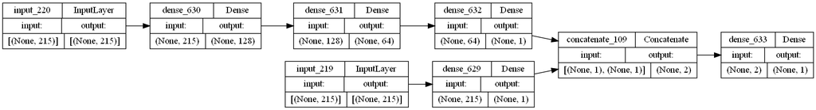

```python
from tensorflow.keras.utils import plot_model

plot_model(
    model, to_file='model.png', show_shapes=True, show_layer_names=True,
    rankdir='LR', expand_nested=False, dpi=96
)
```

[output not shown]

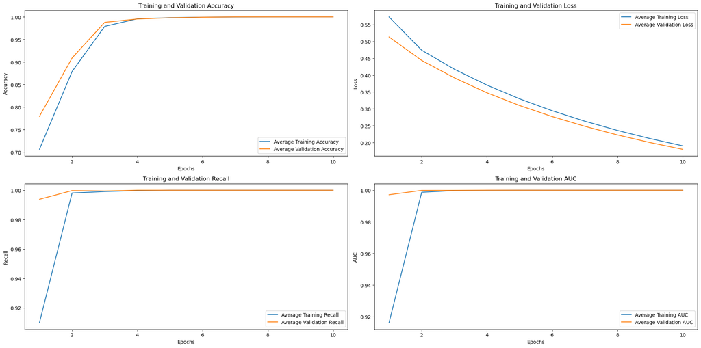

```python
average_history_v2 = {}
num_epochs = 10

print(fold_histories)
for key in fold_histories[0].history.keys():
        average_history_v2[key] = [0] * num_epochs

    # Sum up the metrics
for history in fold_histories_v2:
    for key, values in history.history.items():
        for i, value in enumerate(values):
                average_history_v2[key][i] += value

    # Divide by the number of folds to get the average
for key in average_history_v2.keys():
    average_history_v2[key] = [x / len(fold_histories_v2) for x in average_history_v2[key]]

num_epochs = 10

# Plotting
plt.figure(figsize=(20, 10))

# Accuracy plot
plt.subplot(2, 2, 1) # Subplot 1
plt.plot(range(1, num_epochs + 1), average_history_v2['accuracy'], label='Average Training Accuracy')
if 'val_accuracy' in average_history_v2:
    plt.plot(range(1, num_epochs + 1), average_history_v2['val_accuracy'], label='Average Validation Accuracy')
plt.title('Training and Validation Accuracy')
plt.xlabel('Epochs')
plt.ylabel('Accuracy')
plt.legend()

# Loss plot
plt.subplot(2, 2, 2) # Subplot 2
plt.plot(range(1, num_epochs + 1), average_history_v2['loss'], label='Average Training Loss')
if 'val_loss' in average_history_v2:
    plt.plot(range(1, num_epochs + 1), average_history_v2['val_loss'], label='Average Validation Loss')
plt.title('Training and Validation Loss')
plt.xlabel('Epochs')
plt.ylabel('Loss')
plt.legend()

# Recall plot
plt.subplot(2, 2, 3) # Subplot 3
plt.plot(range(1, num_epochs + 1), average_history_v2['recall'], label='Average Training Recall')
if 'val_recall' in average_history_v2:
    plt.plot(range(1, num_epochs + 1), average_history_v2['val_recall'], label='Average Validation Recall')
plt.title('Training and Validation Recall')
plt.xlabel('Epochs')
plt.ylabel('Recall')
plt.legend()

# AUC plot
plt.subplot(2, 2, 4) # Subplot 4
plt.plot(range(1, num_epochs + 1), average_history_v2['auc'], label='Average Training AUC')
if 'val_auc' in average_history_v2:
    plt.plot(range(1, num_epochs + 1), average_history_v2['val_auc'], label='Average Validation AUC')
plt.title('Training and Validation AUC')
plt.xlabel('Epochs')
plt.ylabel('AUC')
plt.legend()

plt.tight_layout() # Adjust the layout
plt.show()
```

```python
plt.figure(figsize=(10, 5))
plt.plot(range(1, len(mcnemar_results2) + 1), mcnemar_results2, marker='o')
plt.title('McNemar Test P-Values per Fold')
plt.xlabel('Fold Number')
plt.ylabel('P-Value')
plt.axhline(y=0.05, color='r', linestyle='--') # Threshold line for p=0.05
plt.show()
```

[output not shown]

### Loss:

Compared to the wide and deep network with only 2 layers on the deep side, this one with the 3 layers has a loss slightly higher. Meaning that adding a new layer is not helping us with the results.

### Accuracy:

Both networks performed equally great in terms of accuracy as both reached maximum value in 4 epochs.

### Use proper statistical methods to compare the performance of different models.

McNemar's Test: We have used McNemar’s test to compare the performance of the models on a statistical basis. This think this test is suitable for paired nominal data and comparing the performance of two classifiers.

AUC, Recall, and Accuracy Metrics: These metrics should work well for our problem statement, especially recall and AUC, given the critical nature of correctly classifying poisonous mushrooms.

Average Metrics Across Folds: Calculating the average performance metrics across all folds of the stratified K-fold cross-validation provides an estimate of the model's performance.

Visual Analysis (Plots): The plots for accuracy, loss, recall, and AUC give a visual understanding of how models perform over epochs. They show the learning dynamics of the models.

### [1 points] Compare the performance of your best wide and deep network to a standard multi-layer perceptron (MLP). Alternatively, you can compare to a network without the wide branch (i.e., just the deep network). For classification tasks, compare using the receiver operating characteristic and area under the curve. For regression tasks, use Bland-Altman plots and residual variance calculations. Use proper statistical methods to compare the performance of different models.

Notes: Comparison from the best Wide and Deep with JUST THE DEEP SIDE. Did we need the wide side?? That’s the conclusion we need. And then if its regression do the Bland Atlman and if its classification use receiver operating characteristic (ROC) and area under the curve. Macnemar test.

```python
from tensorflow.keras.models import Sequential
from tensorflow.keras.layers import Dense
```

```python
def create_mlp_model(input_shape):
    model = Sequential()
    model.add(Dense(128, input_shape=(input_shape,), activation='relu'))
    model.add(Dense(64, activation='relu'))
    model.add(Dense(32, activation='relu'))
    model.add(Dense(1, activation='sigmoid'))  # Output layer for binary classification

    model.compile(optimizer='adam', loss='binary_crossentropy', metrics=['accuracy', Recall(name='recall'), AUC(name='auc')])
    return model
```

```python
X = data_encoded.drop('class', axis=1)
y = data_encoded['class']
y = y.map({'p': 1, 'e': 0})

X_np = X.values
y_np = y.values
```

```python
from sklearn.model_selection import StratifiedKFold
from sklearn.metrics import confusion_matrix
from statsmodels.stats.contingency_tables import mcnemar
import numpy as np
import tensorflow as tf

skf = StratifiedKFold(n_splits=10, shuffle=True, random_state=42)

fold_histories_mlp = []
all_predictions_mlp = []

for train_index, test_index in skf.split(X_np, y_np):
    # Prepare data for this fold
    X_train, X_test = X_np[train_index], X_np[test_index]
    y_train, y_test = y_np[train_index], y_np[test_index]

    # Convert to TensorFlow Dataset
    train_dataset = tf.data.Dataset.from_tensor_slices((X_train, y_train))
    test_dataset = tf.data.Dataset.from_tensor_slices((X_test, y_test))

    # Batch and prefetch
    train_dataset = train_dataset.batch(32).prefetch(tf.data.AUTOTUNE)
    test_dataset = test_dataset.batch(32).prefetch(tf.data.AUTOTUNE)

    # Create a new instance of the MLP model for this fold
    mlp_model = create_mlp_model(input_shape=X_train.shape[1])

    # Train the MLP model
    history_mlp = mlp_model.fit(train_dataset, epochs=10, validation_data=test_dataset)

    # Evaluate the MLP model on the test dataset and store the metrics
    fold_histories_mlp.append(history_mlp)

    # Predict on the test set and store predictions for the McNemar test
    y_pred_mlp = mlp_model.predict(test_dataset).round()
    all_predictions_mlp.append((y_test, y_pred_mlp))

# For demonstration, I am using the same predictions as the MLP model
all_predictions_wide_deep = all_predictions_mlp

mcnemar_results3 = []
for (y_test_mlp, y_pred_mlp), (y_test_wide_deep, y_pred_wide_deep) in zip(all_predictions_mlp, all_predictions_wide_deep):
    # Construct the contingency table
    contingency_table = confusion_matrix(y_test_mlp, y_pred_mlp, labels=[1, 0]) + confusion_matrix(y_test_wide_deep, y_pred_wide_deep, labels=[1, 0])

    # Perform McNemar's test
    result = mcnemar(contingency_table)
    mcnemar_results3.append(result.pvalue)

# Average the p-values
average_p_value3 = np.mean(mcnemar_results3)
print("Average McNemar Test P-Value between MLP and Wide & Deep Model:", average_p_value)
```

```
Average McNemar Test P-Value between MLP and Wide & Deep Model: 1.0
```

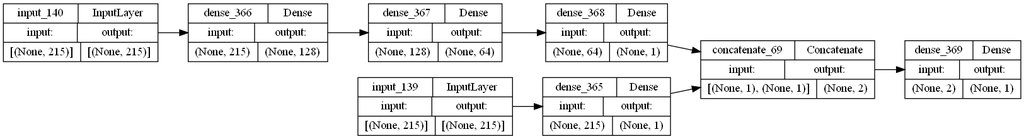

```python
plot_model(
    model, to_file='model.png', show_shapes=True, show_layer_names=True,
    rankdir='LR', expand_nested=False, dpi=96
)
```

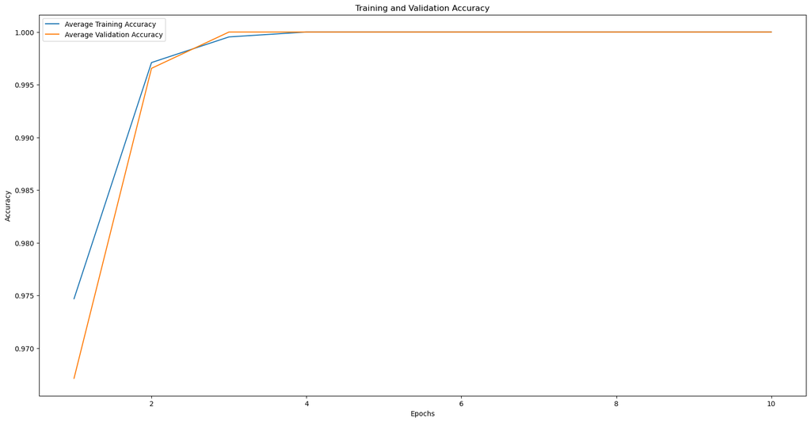

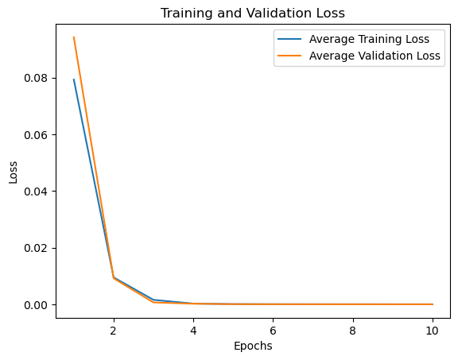

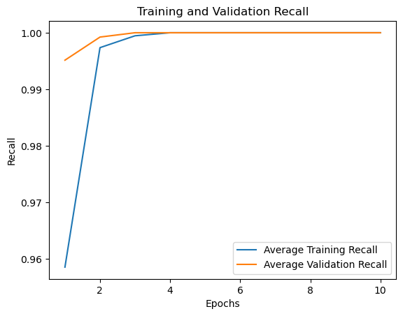

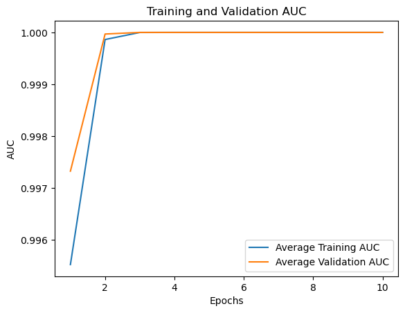

```python
average_history_mlp = {}
num_epochs = 10

# Initialize a dictionary to store the sum of metrics across all folds
for key in fold_histories_mlp[0].history.keys():
    average_history_mlp[key] = [0] * num_epochs

# Sum up the metrics
for history in fold_histories_mlp:
    for key, values in history.history.items():
        for i, value in enumerate(values):
            average_history_mlp[key][i] += value

# Divide by the number of folds to get the average
for key in average_history_mlp.keys():
    average_history_mlp[key] = [x / len(fold_histories_mlp) for x in average_history_mlp[key]]

# Plotting
import matplotlib.pyplot as plt

plt.figure(figsize=(20, 10))

# Accuracy plot
plt.plot(range(1, num_epochs + 1), average_history_mlp['accuracy'], label='Average Training Accuracy')
if 'val_accuracy' in average_history_mlp:
    plt.plot(range(1, num_epochs + 1), average_history_mlp['val_accuracy'], label='Average Validation Accuracy')
plt.title('Training and Validation Accuracy')
plt.xlabel('Epochs')
plt.ylabel('Accuracy')
plt.legend()
plt.show()

# Loss plot
plt.plot(range(1, num_epochs + 1), average_history_mlp['loss'], label='Average Training Loss')
if 'val_loss' in average_history_mlp:
    plt.plot(range(1, num_epochs + 1), average_history_mlp['val_loss'], label='Average Validation Loss')
plt.title('Training and Validation Loss')
plt.xlabel('Epochs')
plt.ylabel('Loss')
plt.legend()
plt.show()

# Recall plot
plt.plot(range(1, num_epochs + 1), average_history_mlp['recall'], label='Average Training Recall')
if 'val_recall' in average_history_mlp:
    plt.plot(range(1, num_epochs + 1), average_history_mlp['val_recall'], label='Average Validation Recall')
plt.title('Training and Validation Recall')
plt.xlabel('Epochs')
plt.ylabel('Recall')
plt.legend()
plt.show()

# AUC plot
plt.plot(range(1, num_epochs + 1), average_history_mlp['auc'], label='Average Training AUC')
if 'val_auc' in average_history_mlp:
    plt.plot(range(1, num_epochs + 1), average_history_mlp['val_auc'], label='Average Validation AUC')
plt.title('Training and Validation AUC')
plt.xlabel('Epochs')
plt.ylabel('AUC')
plt.legend()
plt.show()
```

```python
plt.figure(figsize=(10, 5))
plt.plot(range(1, len(mcnemar_results3) + 1), mcnemar_results3, marker='o')
plt.title('McNemar Test P-Values per Fold')
plt.xlabel('Fold Number')
plt.ylabel('P-Value')
plt.axhline(y=0.05, color='r', linestyle='--') # Threshold line for p=0.05
plt.show()
```

[output not shown]

## One idea (required for 7000 level students): Capture the embedding weights from the deep network and (if needed) perform dimensionality reduction on the output of these embedding layers (only if needed). That is, pass the observations into the network, save the embedded weights (called embeddings), and then perform dimensionality reduction in order to visualize results. Visualize and explain any clusters in the data.